# CMC Research Group - Consumo, mercados y cultura

## **CMC** Consumo, mercados y cultura

#### Universitat Autonoma de Barcelona

Nuestro grupo de investigación está reconocido y financiado por la Generalitat de Catalunya, 2014-SGR-502, y financiado por el Plan Nacional de I+D+i de España (actualmente ECO2011-29558-C02-01). Los problemas de investigación los abordamos con un enfoque interdisciplinar (sociología, economía, antropología, management, derecho, marketing, computación), colaborativo (UAB, University of Haifa (Israel), UPC, URV, University of Varsow (Polonia)) e internacional (España, Israel, Polonia, USA). Nuestro ámbito de investigación es las ciencias sociales, actualmente estudiamos la estructuración de las prácticas culturales, la experiencia ocio, en la computación aplicada al análisis de datos qualitativos (CAQDAS), y la computación en las ciencias sociales, además promover la transferencia de tecnología de investigación.

[figure not shown]

[figure not shown]

[figure not shown]

[figure not shown]

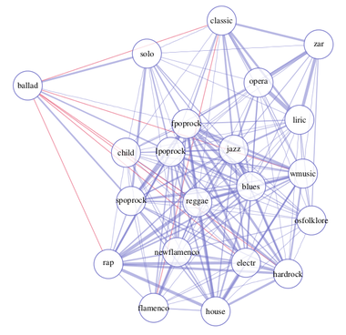

#### Network of Music Genres

El grupo de investigación está adscrito a la Universitat Autònoma de Barcelona, al Centre d’Estudis i de Recerca d’Humanitats i al Dept. d’empresa, aunque sus investigadores proceden de diversos departamentos (derecho, antropología y sociología, economía, management, informática) y universidades.

Nuestro propósito es investigar cómo el orden social influye en el consumo y la producción de las expresiones culturales. Epistemologícamente partimos de la premisa de que el conocimiento está socialmente construido y la sociedad jerárquicamente organizada; por ello el consumo, una actividad simbólica que nos relaciona con otros individuos y que hace visible las diferencias sociales, es de esperar que esté jerarquizado de una manera homóloga a como lo está la sociedad, facilitando así la reproducción de las diferencias sociales. La teoría sugiere que el consumo, y también la producción, mostrará una organización social jerarquizada de manera homóloga a como lo está la sociedad. Este propósito de investigación requiere una visión interdisciplinaria y se concreta en estos momentos en los siguientes proyectos de investigación: 1) La estratificación de la cultura, 2) La experiencia de ocio, 3) Computater Assisted Qualitative Data Anaalysis (CAQDAS), 4) Computational Social Sciences.

# Research

## Current Projects

### The stratifiction of culture

The stratification of leisure stream of research is based on P. Bourdieu (1979) groundbreaking monograph, *La Distiction*, published in english in 1984. Bourdieu (1979/1984) has developed a social theory of cultural practices grounded on the data he gathered about the French in the 70s. Making use of Geometrical Data Analysis methods, concretely MCA, he developed a cultural space of French lifestyles. Then he related the social to the lifestyles space through the conscept of *habitus*. So individuals in priviledged social positions exibit and habit of distinction and individuals in underpriviledged social positions, one of necessity.

The numerous contributions made by Bourdieu (1979) have placed consumption, and especially the consumption of art, in a social and political context of production and reproduction of social differences. Bourdieu and co-workers (Bourdieu, Darbel and Schnapper, 2003), Peterson (1992, 1997, 2005) and US colleagues (Peterson and Simkus, 1992; Peterson and Kern, 1996) have made the pioneering contributions necessary to place the cultural habits of consumers in Western countries on the social stratification map.

Our group has contributed much of the work of drawing the corresponding map for Spain (López-Sintas and García-Álvarez, 2002a; López-Sintas and García-Álvarez 2002b; Lopez-Sintas and García-Álvarez, 2002c; López-Sintas and García -Álvarez, 2006; García-Alvarez, Kartz-Gerro and López-Sintas, 2007; López-Sintas, Garcia-Alvarez and Filimon 2008; López-Sintas and Katz-Gerro 2005; Filimon, López-Sintas and Padrós-Reig, 2011).

Digital cultural expressions are also notably absent from interpretive research into the meanings produced during consumption. As an example, consider the articles published on digital games in 2003 in Information, Communication and Society, Issue 4, Volume 6. Of the seven original articles published, none interprets the meanings produced during the consumption experience; rather, all are interpretations of games from the production and the media side. Studies that have addressed the consumer topic have been conducted using, not an interpretive approach, but the positivist paradigm and quantitative methods.

[`Working paper A (SSRN)`](http://papers.ssrn.com/abstract=2519249) `Project official website`

### The leisure experience

In recent years, many of the traditional cultural expressions (music, movies, books, comic books) have become digital, sharing technologies and consumption patterns typical of the new digital cultural expressions, namely, video games, thereby merging culture and technology. The digital transformation of traditional cultural expressions and their extension to games not only has implications for the business model of the cultural industries but also for digital leisure and social uses of the digital technologies.

While industry and governments have striven to maintain control over traditional business models (as with the draft ‘Sinde law’ in Spain), we know little of the use that the consumer makes, during leisure time, of both digital cultural expressions and digital technologies. Moreover, digital games were not deemed worthy of study until recently (Bryce and Rutter 2006) and, in Spain, were only recognised as a form of cultural expression in 2009.

Despite the economic importance of digital cultural expressions, they have been studied but little and in a segmented way, as follows: (1) the use of the information and communication technologies (ICTs); (2) the use of technology in leisure activities, recently including digital games; and (3) the consumption of cultural expressions. However, these three knowledge domains intersect when we study the consumption of digital cultural expressions during leisure time and spaces.

The purpose of this project is to study and understand the interdependence between the consumption of digital cultural expressions in different leisure spaces and the digital technologies used. We depart from two hypotheses: (1) physical and digital spaces are interconnected through the individual activities performed in both; and (2) the places where consumption activities take place have certain symbolic properties that imbue the consumption experiences in that space.

[`Working paper A (SSRN)`](http://papers.ssrn.com/abstract=2519249) `Project official website` `Project official website`

### Computer Assisted Qualitative Data Analysis Software

CAQDAS offer tools that assit researchs with the procedures of involved during the process of conducting a qualitative research project, such as transcription of texts, managing texts, coding and text intepretation (content analysis, narrative analysis, thematic analysis, grounded theory, case and cross-case analysis, etc.)

We offer practical support, training and information in the use of a range of software programs designed to assist qualitative data analysis under the Framework of the Advanced Seminar in Qualitative Research (SAIC). [SAIC](http://saic.cerhum.es) is a platfrom for debate concerning the methodological and epistemological issues arising from the use of such software packages.

We have cofounded the *Spanish Associacion of Qualitative Research*, [Espacual](http://www.espacual.es). The aim of Espacual is to promote the best practices in qualitative research among the communitiy of Spanish researchers. It organizaces biannually the international conference Iberacual.

### Computational social sciences

We have are contributing to the developoment of an open data analysis framework. We contributed to the international development of the editor for ethnographers, EdEt, initially developed by Iwona Kaliszewska (Warsow University) and Sebastian Kaliszeski (now at Google).

Currently we aim at developing a qualitative data analysis framework for the open R computational environment for data a nalysis (R Core Team 2014). The r-project is an award winning academic project for computational data analysis. Concretely we are developing an addon for transforming Rstudio user interface for R into a framework for qualitative data analysis. The framework should be open, collaborative in its development, design for working research teams simulteaneouly, simple, transparent, modular, be able to work with every kind of texts, and be integrate n the R computational environment.

# Publications

## Peer-reviewed Papers

- López-Sintas, Jordi, Àngel Cebollada, Nela Filimon, and Abaghan Gharhaman. “Music access patterns: A social interpretation.” Poetics (2014).

  [`Official link (Pay-walled)`](http://www.sciencedirect.com/science/article/pii/S0304422X14000539) [`DOI: 10.1016/j.poetic.2014.09.003`](http://dx.doi.org/10.1016/j.poetic.2014.09.003) [`ResearchGate`](http://www.researchgate.net/publication/267159718_Music_access_patterns_A_social_interpretation)

# Etc.

## Miscellaneous contents and pages

- Collaboration Techniques We Have

# Contacts

## Physical Address

- Universitat Autònoma de Barcelona  
  School of Economics and Business, Department of Business  
  Edifici B, 08193-Bellaterra, Barcelona, Spain

## URLs & Social networks

- [cms.uab.es](http://cmc.uab.es/)
- [www.facenook.com/**cmcgroup**](http://www.facebook.com/cmcgroup)
- [www.twitter.com/cmc @cmcgroup](http://www.twitter.com/cmcgroup)